# Stats with R and RStudio

# Getting help for *R* functions

Need help? Type **`help()`**.

```r
help(plot)
```

A question? Type `?`

```r
?plot
```

# Exercise: improve Poisson density plot

1. Do not (yet) look the next slide.
2. Read the help page for the `dpois()`function.
3. draw a plot that provides a didactic illustration of the Poisson density.

# Improve the plot: type = histogram

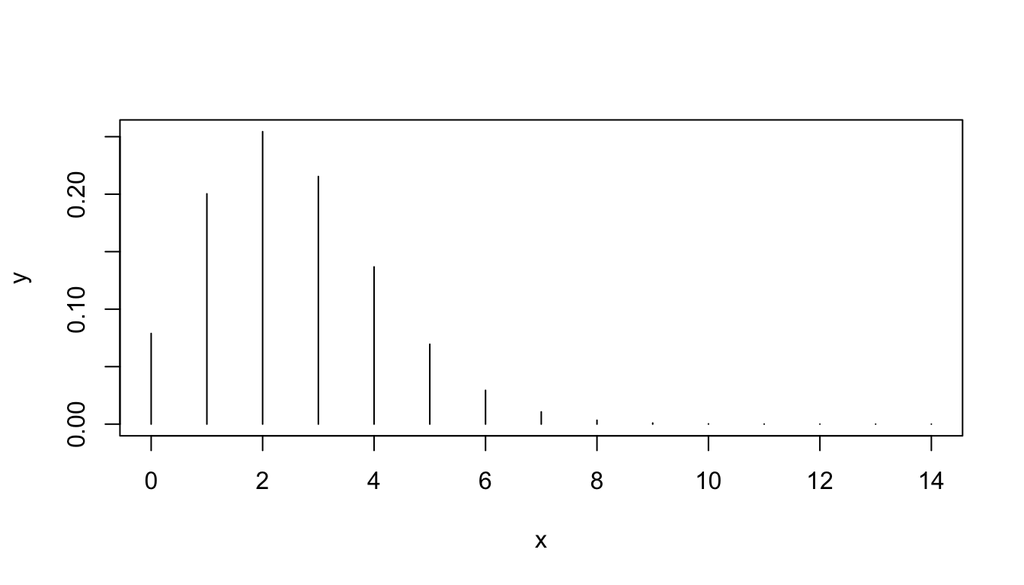

```r
x <- 0:14
lambda <- 2.54
y <- dpois(x, lambda)
plot(x,y, type="h")
```

# Improve the plot: Add a title

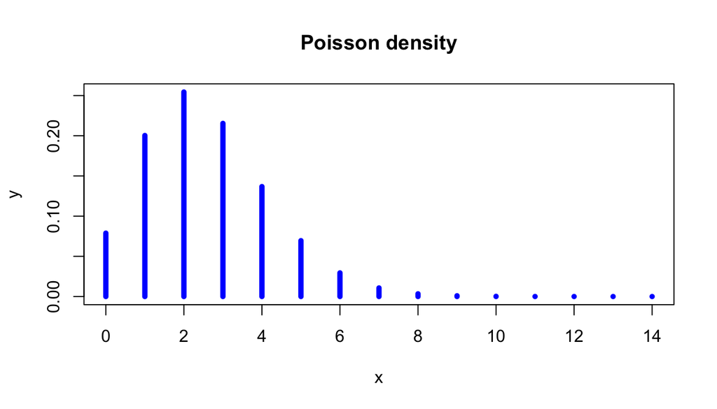

```r
plot(x,y, type="h", lwd=5, col="blue",
     main="Poisson density")
```

# Improve the plot: define axis labels

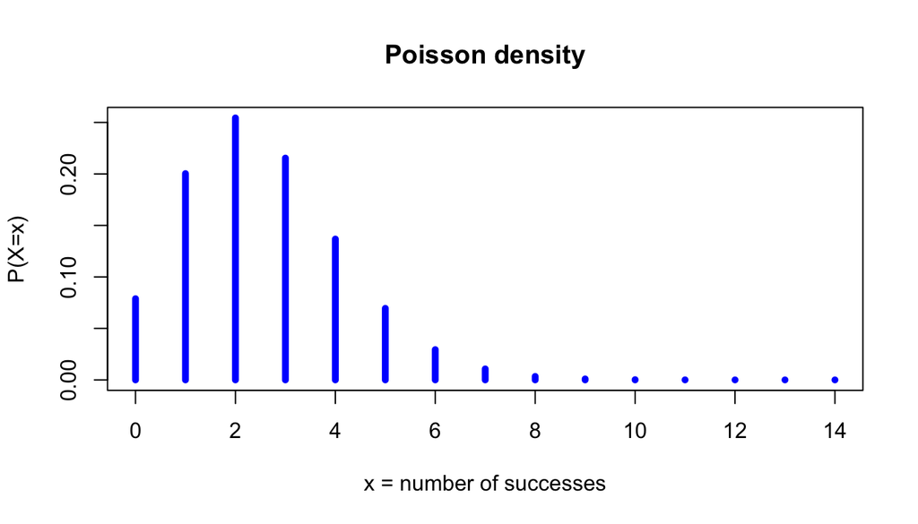

```r
plot(x,y, type="h", lwd=5, col="blue",
     main="Poisson density",
     xlab="x = number of successes",
     ylab="P(X=x)")
```

# Improve the plot: add a legend

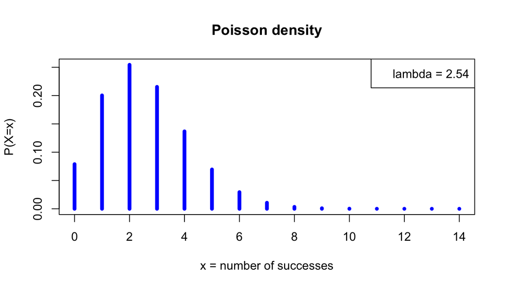

```r
plot(x,y, type="h", lwd=5, col="blue",
     main="Poisson density",
     xlab="x = number of successes",
     ylab="P(X=x)")
legend("topright", paste("lambda =", lambda))
```

# Poisson: a family of curves

**Exercice:** explore the properties of the Poisson density function, by changing the rang of $x$ values, and the $\lambda$ parameter.

# Solution: a family of Poisson curves

$lambda=0.01$

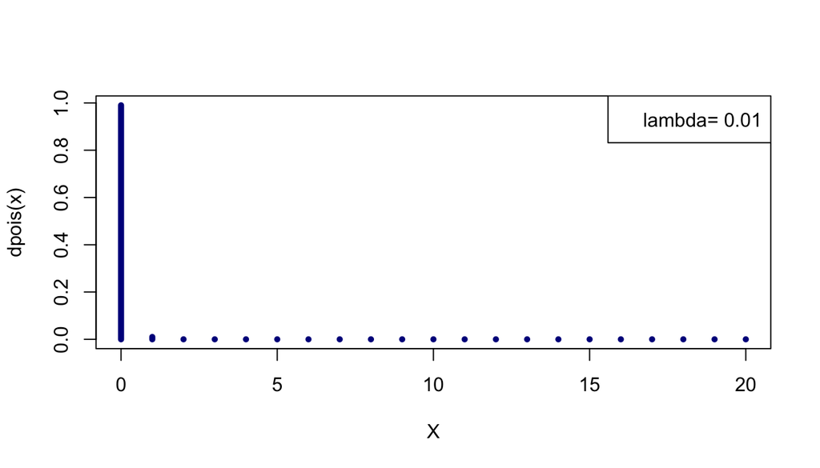

```r
lambda <- 0.01
x <- 0:20
plot(x, dpois(x,lambda=lambda), type="h",
     col="darkblue", lwd=5, xlab="X",ylab="dpois(x)")
legend("topright", paste("lambda=",lambda))
```

# Solution: a family of Poisson curves

$lambda=0.1$

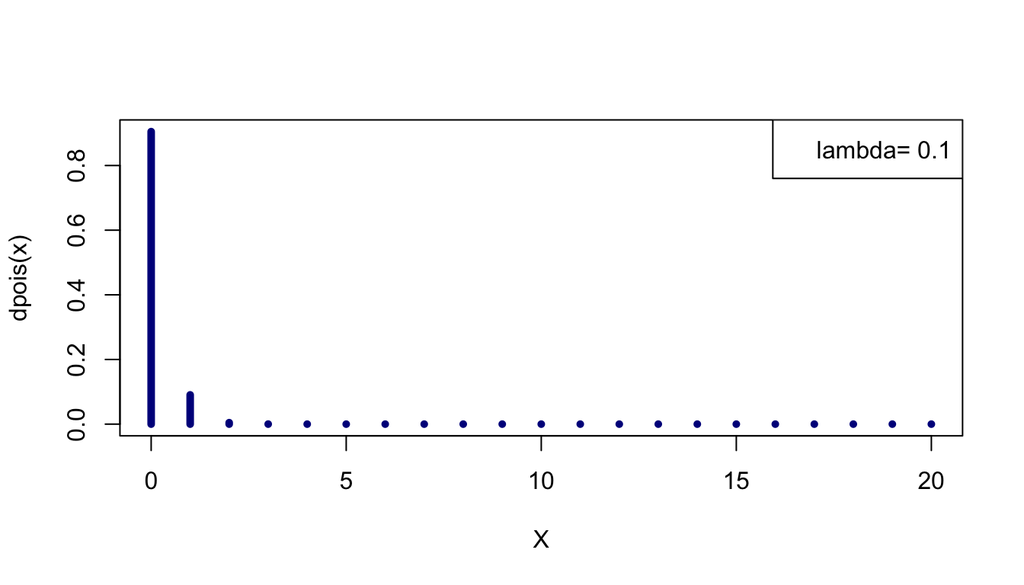

```r
lambda <- 0.1
x <- 0:20
plot(x, dpois(x,lambda=lambda), type="h",
     col="darkblue", lwd=5, xlab="X",ylab="dpois(x)")
legend("topright", paste("lambda=",lambda))
```

# Solution: a family of Poisson curves

$lambda=1$

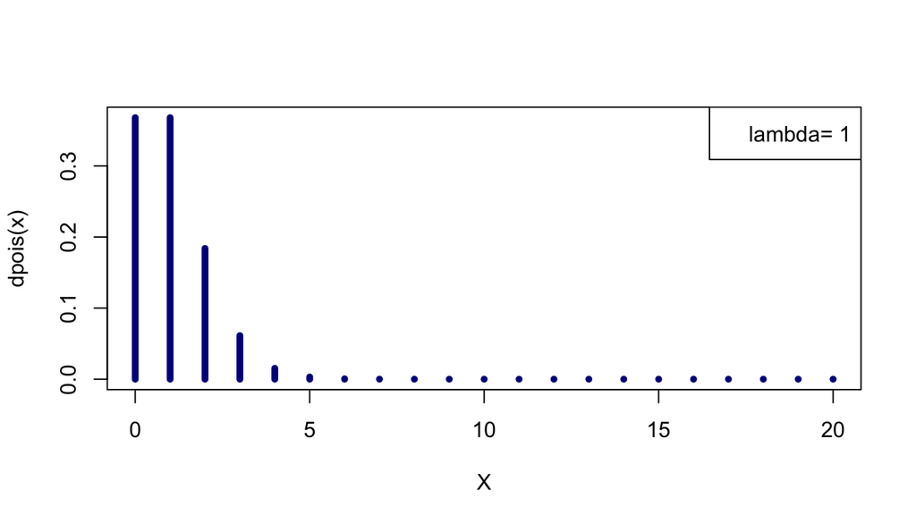

```r
lambda <- 1
x <- 0:20
plot(x, dpois(x,lambda=lambda), type="h",
     col="darkblue", lwd=5, xlab="X",ylab="dpois(x)")
legend("topright", paste("lambda=",lambda))
```

# Solution: a family of Poisson curves

$lambda=2$

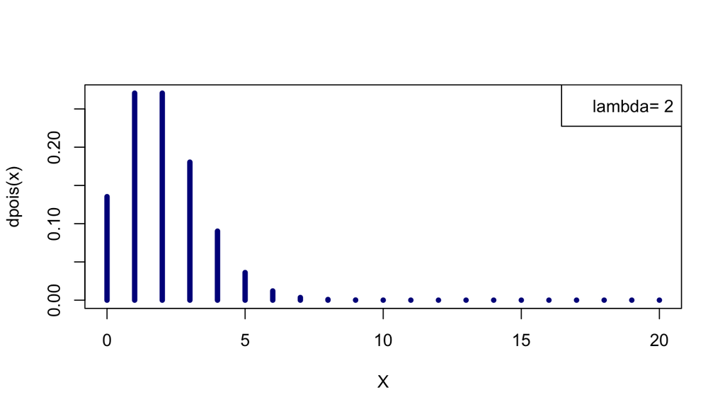

```r
lambda <- 2
x <- 0:20
plot(x, dpois(x,lambda=lambda), type="h",
     col="darkblue", lwd=5, xlab="X",ylab="dpois(x)")
legend("topright", paste("lambda=",lambda))
```

# Solution: a family of Poisson curves

$lambda=5$

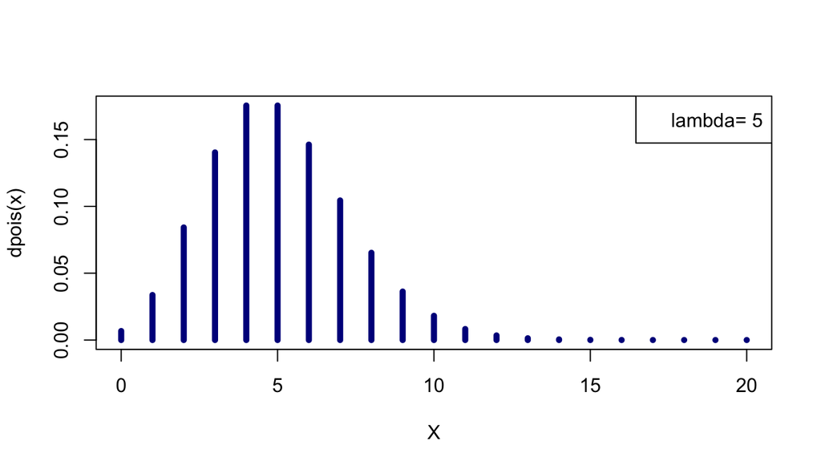

```r
lambda <- 5
x <- 0:20
plot(x, dpois(x,lambda=lambda), type="h",
     col="darkblue", lwd=5, xlab="X",ylab="dpois(x)")
legend("topright", paste("lambda=",lambda))
```

# Solution: a family of Poisson curves

$lambda=5$

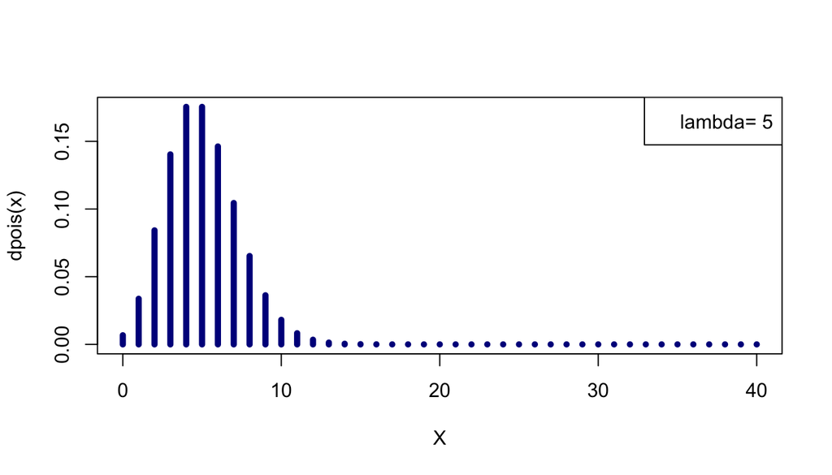

```r
lambda <- 5
x <- 0:40
plot(x, dpois(x,lambda=lambda), type="h",
     col="darkblue", lwd=5, xlab="X",ylab="dpois(x)")
legend("topright", paste("lambda=",lambda))
```

# Solution: a family of Poisson curves

$lambda=10$

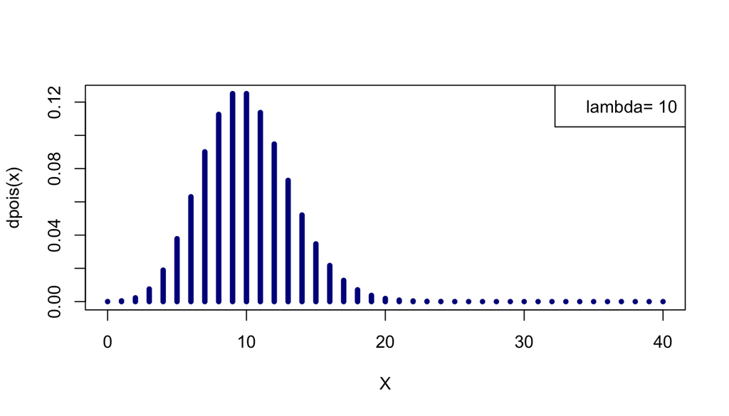

```r
lambda <- 10
x <- 0:(4*lambda)
plot(x, dpois(x,lambda=lambda), type="h",
     col="darkblue", lwd=5, xlab="X",ylab="dpois(x)")
legend("topright", paste("lambda=",lambda))
```

# Solution: a family of Poisson curves

$lambda=20$

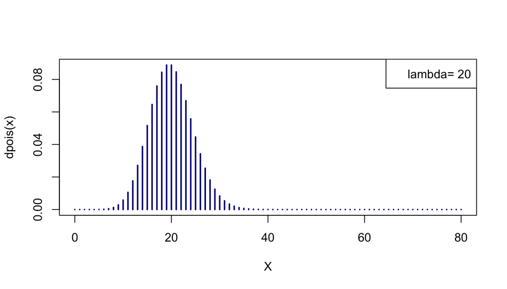

```r
lambda <- 20
x <- 0:(4*lambda)
plot(x, dpois(x,lambda=lambda), type="h",
     col="darkblue", lwd=2, xlab="X",ylab="dpois(x)")
legend("topright", paste("lambda=",lambda))
```

# Solution: a family of Poisson curves

$lambda=30$

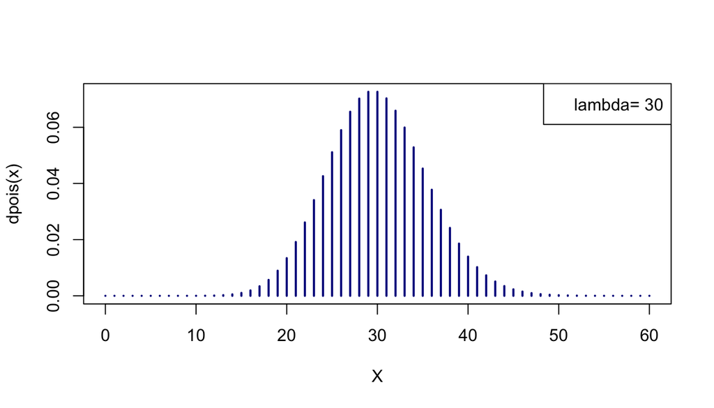

```r
lambda <- 30
x <- 0:(2*lambda)
plot(x, dpois(x,lambda=lambda), type="h",
     col="darkblue", lwd=2, xlab="X",ylab="dpois(x)")
legend("topright", paste("lambda=",lambda))
```

# Solution: a family of Poisson curves

$lambda=50$

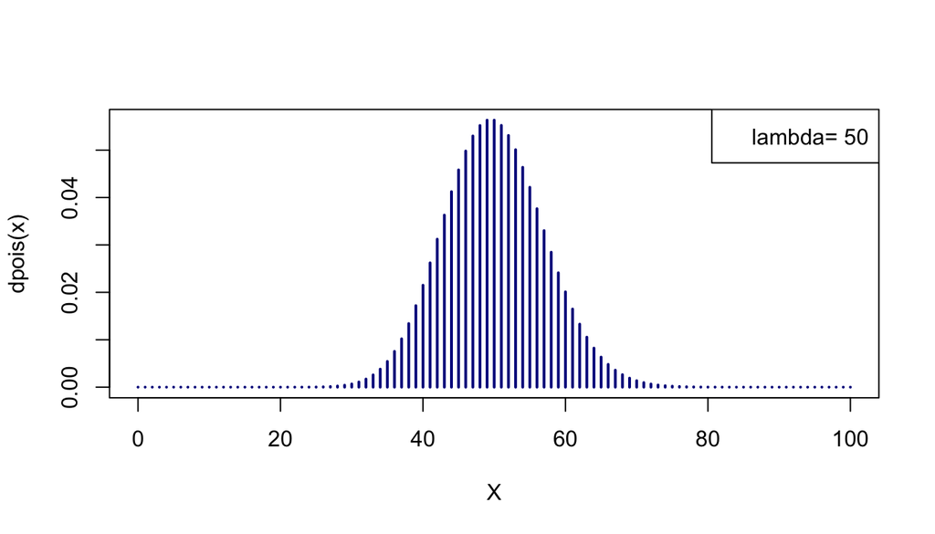

```r
lambda <- 50
x <- 0:(2*lambda)
plot(x, dpois(x,lambda=lambda), type="h",
     col="darkblue", lwd=2, xlab="X",ylab="dpois(x)")
legend("topright", paste("lambda=",lambda))
```

# Solution: a family of Poisson curves

$lambda=100$

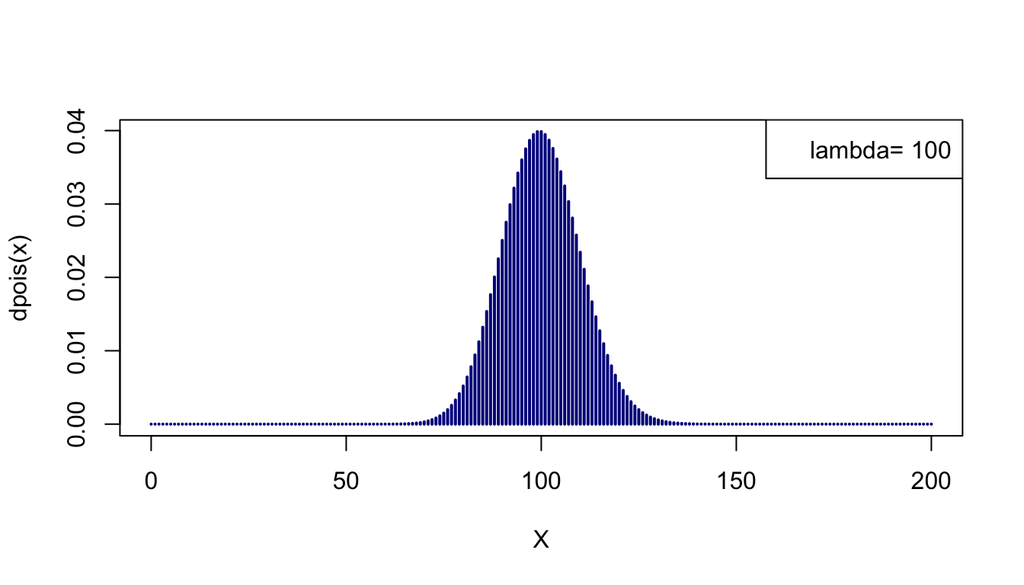

```r
lambda <- 100
x <- 0:(2*lambda)
plot(x, dpois(x,lambda=lambda), type="h",
     col="darkblue", lwd=2, xlab="X",ylab="dpois(x)")
legend("topright", paste("lambda=",lambda))
```

# Solution: a family of Poisson curves

$lambda=1000$

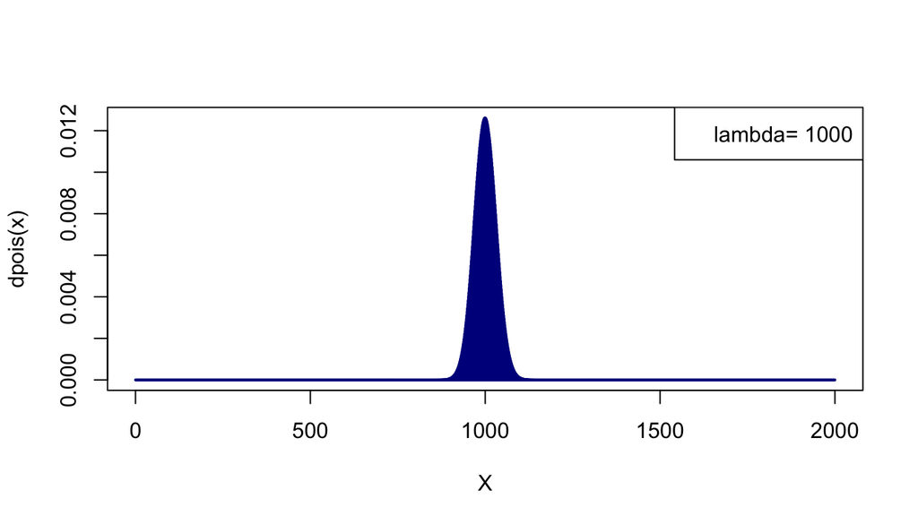

```r
lambda <- 1000
x <- 0:(2*lambda)
plot(x, dpois(x,lambda=lambda), type="h",
     col="darkblue", lwd=2, xlab="X",ylab="dpois(x)")
legend("topright", paste("lambda=",lambda))
```

# Solution: a family of Poisson curves

$lambda=10000$

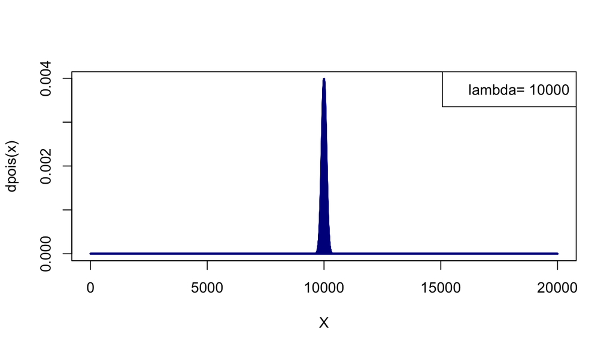

```r
lambda <- 10000
x <- 0:(2*lambda)
plot(x, dpois(x,lambda=lambda), type="h",
     col="darkblue", lwd=2, xlab="X",ylab="dpois(x)")
legend("topright", paste("lambda=",lambda))
```

# Solution: a family of Poisson curves

$lambda=100000$

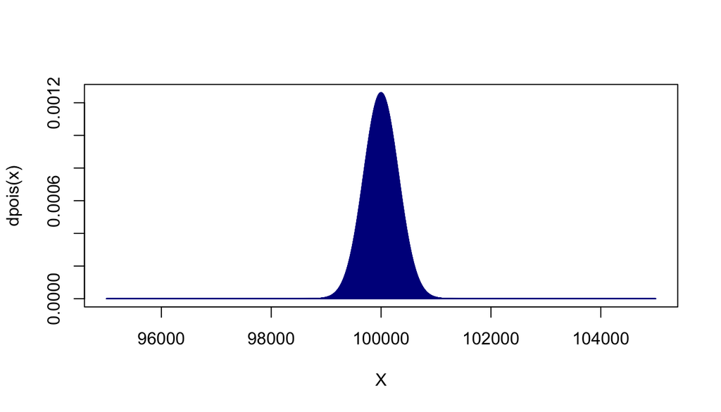

```r
plot(95000:105000, dpois(95000:105000,lambda=100000), type="h", col="darkblue", xlab="X",ylab="dpois(x)")
```

# Before finishing – keep track of your session

Tractability is an important issue in sciences. The *R* function `sessionInfo()` summarizes information about the versions of R, the operating system, and all the libraries used during a session.

[session information not shown]